# MLG

# 5 Tecnicas de diagnostico.

## Algunos gráficos recomendados

- Valores observados yi vs. cada una de las covariables. Grafico exploratorio que permite ver la relación entre la respuesta y las covariables.
- Valores observados yi vs. mi valores predichos. Permite ver la bondad de ajuste del modelo, podemos ver que tanto se asemejan, uno busca que se parezcan, ver que tanto se alejan de la recta a 45 grados.
- Residuos estandarizados vs. mi valores predichos (o transformados en la escala en que la información es constante) o vs. ni. Si el modelo es adecuado, el gráfico no debería mostrar ninguna tendencia (patrón nulo). La transformación de escala se refiere a una transformación específica para cada distribución que mejora la apariencia del eje de las x.
- Residuos estandarizados vs. caso. Permite identificar cual observación tiene cual residuo, entonces buscamos esa directamente y corregimos.
- Residuos estandarizados vs. orden en que se tomaron las mediciones (para analizar posible correlación).
- Residuos estandarizados en el instante t vs. en el instante t-1. patrón habla de asociación, no hay independencia, no debería ocurrir.
- Residuos estandarizados vs. covariable incluida en el modelo. Si hay patrón debo incluir, si no hay patrón está bien dejarla afuera.
- Residuos estandarizados vs. covariable no incluida en el modelo. Si la covariable esta bien cargada no espero ningún patrón. Si hay algún patrón debo modificar la forma en que añadí esa covariable.

## Gráficos para chequear la función de varianza:

- Valor absoluto de los residuos estandarizados vs. valores ajustados (en la escala en la que la información es constante). Una tendencia positiva indica que la función de varianza elegida es tal que la varianza crece demasiado lento con la media. Una tendencia negativa implica lo contrario.
- Varianza muestral vs. media muestral para el caso en que se tengan varias observaciones para cada configuración de las covariables.
- (yi-mi)^2 vs mi.

## Residuos parciales

- Se recomienda graficar residuos parciales para xj vs. xj. Si la escala de la covariable es correcta, el grafico debería aproximarse a una recta. En caso contrario, la forma del grafico podría sugerir la corrección a realizar.

## Como chequear la función de enlace

- Graficar Z^ vs.n^. Si el enlace es adecuado, el grafico debería mostrar aproximadamente una línea recta. Este grafico es no informativo para datos binarios.
- Técnica más formal: Agregar n^2 como covariable en el predictor lineal. Si el cambio de deviance es significativo, puede estar indicando:
  - Mal enlace.
  - Mala escala para una covariable.
  - Ambos.
- Si el cambio en la deviance es no significativo luego el modelo es adecuado.

## Leverage

- Los elementos diagonales hi de la matriz Hat son los leverages. Análogamente a los modelos lineales, se suele considerar que la observación i tiene alto leverage si hi > 2p/n.
  - Nota: Para MLG, un punto en el extremo del rango de las x no necesariamente tiene leverage alto (pues su valor depende también de W^ ).

## Distancia de Cook

- Un valor grande de Di implica que las estimaciones cambian mucho cuando la observación i es retirada la observación i es influyente.
  - El Di se compara con 1 o bien entre los valores obtenidos.

## Residuos deletion (jackknife o likelihood residuals):

- Grandes valores para los residuos jackknife permiten detectar outliers.

## Q-Q plot y half-normal plot

- El objetivo es buscar puntos extremos en estos gráficos, fuera de la tendencia general.

## Cómo extraer medidas de diagnóstico en R

```r
#fit$fitted.values # m^ para el modelo ajustado fit
#fit$linear.predictors #n^ para el modelo ajustado fit
#glm.diag{res} #Vector de residuos jackknife.
#glm.diag{rd} #Vector de residuos de deviance estandarizados.
#glm.diag{rp} #Vector de residuos de Pearson estandarizados.
#glm.diag{cook} #Vector de distancias de Cook.
#glm.diag{h} #Vector de leverages.
#residuals(fit,type="partial") #Residuos parciales para fit
#residuals(fit,type="working")+fit$linear.predictors #Z^ para fit
#halfnorm {Faraway} #Half-normal plot
```

# 6 Modelo para datos binarios

## Enlaces mas usados:

```r
#(family = binomial)
#(link = “logit”) #Logit, enlace canonico
#(link = “probit”) #Probit
#(link = “cloglog”) #Complemento log-log
```

## Ejemplo Horseschoe crab data

```r
library(glm2)
datos<- crabs
datos$flag<- 0
for (i in 1:nrow(datos)) {
  if(datos$Satellites[i] > 0){datos$flag[i]=1
  } else {
    datos$flag[i]=0
  }
}
sat<- datos$flag
ancho<-datos$Width
fit<-glm(sat~ancho,family=binomial) #Modelo link logit canonico
summary(fit)
```

```
##
## Call:
## glm(formula = sat ~ ancho, family = binomial)
##
## Deviance Residuals:
##     Min       1Q   Median       3Q      Max
## -2.0281  -1.0458   0.5480   0.9066   1.6942
##
## Coefficients:
##             Estimate Std. Error z value Pr(>|z|)
## (Intercept) -12.3508     2.6287  -4.698 2.62e-06 ***
## ancho         0.4972     0.1017   4.887 1.02e-06 ***
## ---
## Signif. codes:  0 '***' 0.001 '**' 0.01 '*' 0.05 '.' 0.1 ' ' 1
##
## (Dispersion parameter for binomial family taken to be 1)
##
##     Null deviance: 225.76  on 172  degrees of freedom
## Residual deviance: 194.45  on 171  degrees of freedom
## AIC: 198.45
##
## Number of Fisher Scoring iterations: 4
```

- Pr(>|z|):
  - Ho = B = 0
  - H1 = B != 0

## Bondad de ajuste en datos desagrupados

### 1) X^2 de Pearson

```r
observados<-c(5,4,17,21,15,20,15,14,9,10,11,18,7,4,3,0)
estimados<-c(3.64,5.31,13.78,24.23,15.94,19.38,15.65,
13.08,10.36,8.69,14.22,14.77,6.06,4.62,2.35,0.92)
X2<-sum(((observados-estimados)^2)/estimados)
X2
```

```
## [1] 5.321602
```

```r
1-pchisq(X2,6)
```

```
## [1] 0.5032752
```

- Prueba de hipotesis:
  - Ho = Modelo es adecuado
  - H1 = Modelo no es adecuado
- No hay evidencias en la muestra para rechazar HO se concluye que el modelo es adecuado.

### 2) Test de Hosmer-Lemeshow

```r
library(ResourceSelection)
```

```
## ResourceSelection 0.3-5   2019-07-22
```

```r
hoslem.test(sat,fitted.values(fit))
```

```
##
##  Hosmer and Lemeshow goodness of fit (GOF) test
##
## data:  sat, fitted.values(fit)
## X-squared = 4.3855, df = 8, p-value = 0.8208
```

- Prueba de hipotesis:
  - Ho = Modelo es adecuado
  - H1 = Modelo no es adecuado
- No hay evidencias en la muestra para rechazar HO se concluye que el modelo es adecuado.

## Interpretacion de los parametros en terminos de chances

```r
exp(coef(fit))
```

```
##  (Intercept)        ancho
## 4.326214e-06 1.644162e+00
```

- La chance de tener un satélite aumenta en un factor de 1.64 (un 64%) cuando el ancho del caparazón aumenta 1 cm.
- exp(B1) representa el cociente de chances (odds ratio) de que ocurra un éxito cuando la covariable x aumenta en una unidad.

## Intervalos de confianza

### Un intervalo de 100(1-α) % de confianza para es:

```r
c(0.4972-1.96*0.1017,0.4972+1.96*0.1017)
```

```
## [1] 0.297868 0.696532
```

```r
# B1^ +- z a/2 * EEBj^

confint.default(fit)
```

```
##                   2.5 %     97.5 %
## (Intercept) -17.5030100 -7.1986254
## ancho         0.2978326  0.6966286
```

### Un intervalo de 100(1-α) % de confianza para el cociente de chances exp(B1) es:

```r
c(exp(0.4972-1.96*0.1017),exp(0.4972+1.96*0.1017))
```

```
## [1] 1.346984 2.006781
```

```r
# exp(B1^ +- z a/2 * EEBj^)

exp(confint.default(fit))
```

```
##                    2.5 %       97.5 %
## (Intercept) 2.503452e-08 0.0007476128
## ancho       1.346936e+00 2.0069749360
```

- No interpretar los resultados del intervalo de confianza para B0.

### Intervalo de 100(1-α) % de confianza para p(x):

- Necesito el intervalo de 100(1-α) % de confianza para n(Xo) = logit(p(Xo))

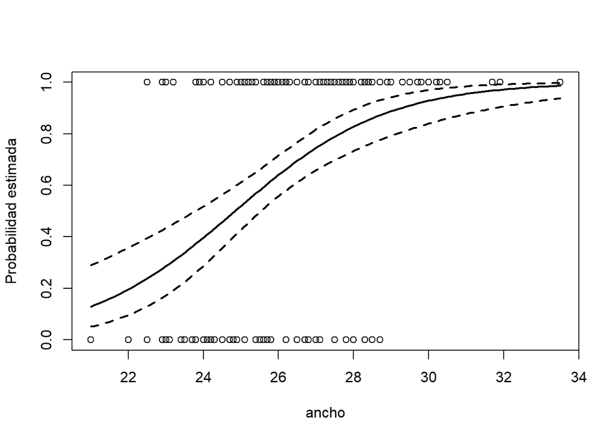

```r
plot(ancho, sat, ylab="Probabilidad estimada")
anchodf <- data.frame(ancho = seq(21,33.5,0.1)) #le doy grilla
eta <- predict(fit, newdata = anchodf, se.fit = TRUE) #se.fit le digo que guarde los errores estandares del n eta
prob <- predict(fit, newdata = anchodf, type = "response") #p(x) predicha para nueva grilla
LIeta <- eta$fit - qnorm(0.975)*eta$se.fit
LSeta <- eta$fit + qnorm(0.975)*eta$se.fit
LIp <- exp(LIeta)/(1 + exp(LIeta)) # bandas de confianza para p
LSp <- exp(LSeta)/(1 + exp(LSeta))
lines(seq(21,33.5,0.1), prob, lwd=2)
lines(seq(21,33.5,0.1),LIp,lty=2,lwd=2)
lines(seq(21,33.5,0.1),LSp,lty=2,lwd=2)
```

## Modelos logit con variables predictoras categóricas * exp(Bi) representa el cociente de chances (odds ratio) entre las categorías i y I (categoría de referencia), i = 1,…, I-1. * Bi=0 La chance de que ocurra un éxito es la misma en la categoría i que en la I.

```r
fav <- c(16,40) #2 respuestas para favorable
desfav <- c(48,20) #2 respuestas para desfavorable
trat <- factor(c("placebo","droga")) #Categorias del tratamiento
fit1 <- glm(cbind(fav,desfav) ~ 1, family = binomial) # asi hay que brindarle los datos para este tipo de modelos. / Estamos en presencia del modelo solo con Bo / MODELO DE INDEPENDENCIA
summary(fit1)
```

```
##
## Call:
## glm(formula = cbind(fav, desfav) ~ 1, family = binomial)
##
## Deviance Residuals:
##      1       2
## -3.337   3.353
##
## Coefficients:
##             Estimate Std. Error z value Pr(>|z|)
## (Intercept)  -0.1942     0.1805  -1.076    0.282
##
## (Dispersion parameter for binomial family taken to be 1)
##
##     Null deviance: 22.377  on 1  degrees of freedom
## Residual deviance: 22.377  on 1  degrees of freedom
## AIC: 33.149
##
## Number of Fisher Scoring iterations: 3
```

```r
1-pchisq(22.377,1)
```

```
## [1] 2.24041e-06
```

- Prueba de hipotesis:
  - Ho = Modelo es adecuado
  - H1 = Modelo no es adecuado
- El modelo de independencia no ajusta, luego si hay relacion, entonces ajusto el modelo con los tratamientos

```r
fit2 <- glm(cbind(fav,desfav) ~ trat, family = binomial)
summary(fit2)
```

```
##
## Call:
## glm(formula = cbind(fav, desfav) ~ trat, family = binomial)
##
## Deviance Residuals:
## [1]  0  0
##
## Coefficients:
##             Estimate Std. Error z value Pr(>|z|)
## (Intercept)   0.6931     0.2739   2.531   0.0114 *
## tratplacebo  -1.7918     0.3979  -4.503  6.7e-06 ***
## ---
## Signif. codes:  0 '***' 0.001 '**' 0.01 '*' 0.05 '.' 0.1 ' ' 1
##
## (Dispersion parameter for binomial family taken to be 1)
##
##     Null deviance: 22.377  on 1  degrees of freedom
## Residual deviance:  0.000  on 0  degrees of freedom
## AIC: 12.772
##
## Number of Fisher Scoring iterations: 3
```

- Prueba de hipotesis:
  - Ho = Modelo es adecuado
  - H1 = Modelo no es adecuado
- El modelo ajusta bien.
- Elige como categoria de referencia la que no figura en la estimacion. Droga.

```r
fitted.values(fit2)
```

```
##         1         2
## 0.2500000 0.6666667
```

```r
exp(coef(fit2)) # OR placebo/droga (eligio/referencia)
```

```
## (Intercept) tratplacebo
##   2.0000000   0.1666667
```

```r
exp(-coef(fit2)) #OR droga/placebo
```

```
## (Intercept) tratplacebo
##         0.5         6.0
```

- La chance de tener respuesta favorable en los pacientes que reciben la droga es 6 veces esa chance en los que reciben placebo.
- Si tenemos mas de una categoria siempre OR respecto a la categoria de referencia.

## Modelo de Regresión Logística Múltiple

### Interpretación de los parámetros

#### Supongamos que xj es continua.

- βj = 0 No hay relación entre la probabilidad de éxito y la variable xj.
- βj > 0 La probabilidad de éxito aumenta a medida que xj aumenta (fijas las restantes covariables).
- βj < 0 La probabilidad de éxito disminuye a medida que xj aumenta (fijas las restantes covariables).
- Además,exp(Bj) representa el cociente de chances de que ocurra un éxito cuando la covariable xj aumenta en una unidad (y las demás variables explicativas están fijas).

#### Supongamos que xj es una variable indicadora representando el nivel k de un factor de clasificación (y no hay términos de interacción).

- βj = 0 La chance de que ocurra un éxito es la misma en la categoría k que en la de referencia.
- βj > 0 La chance de que ocurra un éxito es mayor en la categoría k que en la de referencia.
- βj < 0 La chance de que ocurra un éxito es menor en la categoría k que en la de referencia.
- Además,exp(Bj) representa el cociente de chances de que ocurra un éxito entre la categoría k y la categoría de referencia (para un valor fijo en las demás variables explicativas).

#### Ejemplo raza (blanca y negra) y sexo (femenino y masculino):

- exp(B1) es el odds ratio condicional entre X e Y, fijando Z. Hay asociación homogénea entre X e Y. Hay un odds ratio común para las tablas parciales.
- Cuando B1 = 0 el odds ratio común vale 1. Hay independencia condicional entre X e Y dado Z, X e Y son independientes en cada tabla parcial.

```r
grad<-c(498,878,54,197)
nograd<-c(298,747,89,463)
sexo<-c(1,0,1,0)
raza<-c(1,1,0,0)

fit<-glm(cbind(grad,nograd)~sexo+raza,family=binomial)
summary(fit)
```

```
##
## Call:
## glm(formula = cbind(grad, nograd) ~ sexo + raza, family = binomial)
##
## Deviance Residuals:
##         1          2          3          4
## -0.004812   0.003270   0.011335  -0.005588
##
## Coefficients:
##             Estimate Std. Error z value Pr(>|z|)
## (Intercept) -0.85405    0.07789 -10.964  < 2e-16 ***
## sexo         0.35244    0.08044   4.381 1.18e-05 ***
## raza         1.01547    0.08723  11.641  < 2e-16 ***
## ---
## Signif. codes:  0 '***' 0.001 '**' 0.01 '*' 0.05 '.' 0.1 ' ' 1
##
## (Dispersion parameter for binomial family taken to be 1)
##
##     Null deviance: 1.8006e+02  on 3  degrees of freedom
## Residual deviance: 1.9355e-04  on 1  degrees of freedom
## AIC: 33.029
##
## Number of Fisher Scoring iterations: 2
```

- Residual deviance practimante 0, muy baja no hace falta hacer prueba de X^2. Modelo adecuado.

```r
fitted.values(fit)
```

```
##         1         2         3         4
## 0.6257107 0.5402673 0.3771629 0.2985844
```

```r
exp(coef(fit))
```

```
## (Intercept)        sexo        raza
##   0.4256883   1.4225348   2.7606512
```

```r
#exp(-coef(fit)) interpretaria al reves respecto de la de referencia
```

- La chance de graduarse de la raza blanca (referencia) es de 2,76 veces la chance de graduarse en la raza negra manteniendo fijo el sexo.
- La chance de graduarse del sexo femenino (referencia) es de 1,42 veces la chance de graduarse del sexo masculino manteniendo fijo el sexo.

## 7 Modelos para datos continuos

### Enlaces para respuesta gaussiana, variable respuesta normal:

```r
#(enlace canónico, link = “identity”) Identidad
#(link = “log”) Logaritmico
#(link = “inverse”) Reciproco
```

### Enlaces para variable respuesta Gamma:

```r
#(enlace canónico, link = “inverse”) Reciproco
#(link = “identity”) Identidad
#(link = “log”) Logaritmico
```

### Ejemplo

```r
datos<-matrix(data=c(-1,-1,-1,674,0,-1,-1,1414,1,-1,-1,3636,-1,0,-1,338,0,0,-1,1022,1,0,-1,1568,-1,1,-1,170,0,1,-1,442,1,1,-1,1140,-1,-1,0,370,0,-1,0,1198,1,-1,0,3184,-1,0,0,266,0,0,0,620,1,0,0,1070,-1,1,0,118,0,1,0,332,1,1,0,884,-1,-1,1,292,0,-1,1,634,1,-1,1,2000,-1,0,1,210,0,0,1,438,1,0,1,566,-1,1,1,90,0,1,1,220,1,1,1,360),ncol=4, nrow= 27, byrow=T)
datos<- as.data.frame(datos)
colnames(datos)[1]<- "x1"
colnames(datos)[2]<- "x2"
colnames(datos)[3]<- "x3"
colnames(datos)[4]<- "y"
x1<-datos$x1
x2<-datos$x2
x3<-datos$x3
y<-datos$y
```

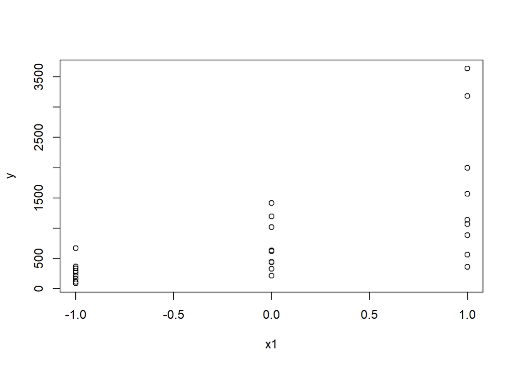

```r
plot(x1,y)
```

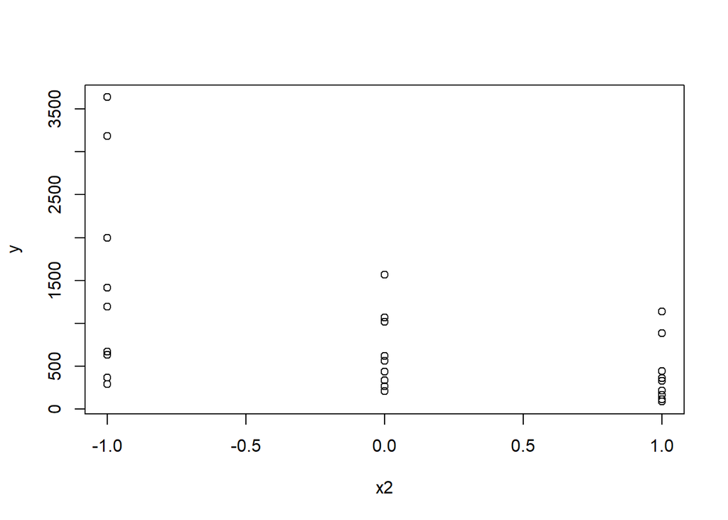

```r
plot(x2,y)
```

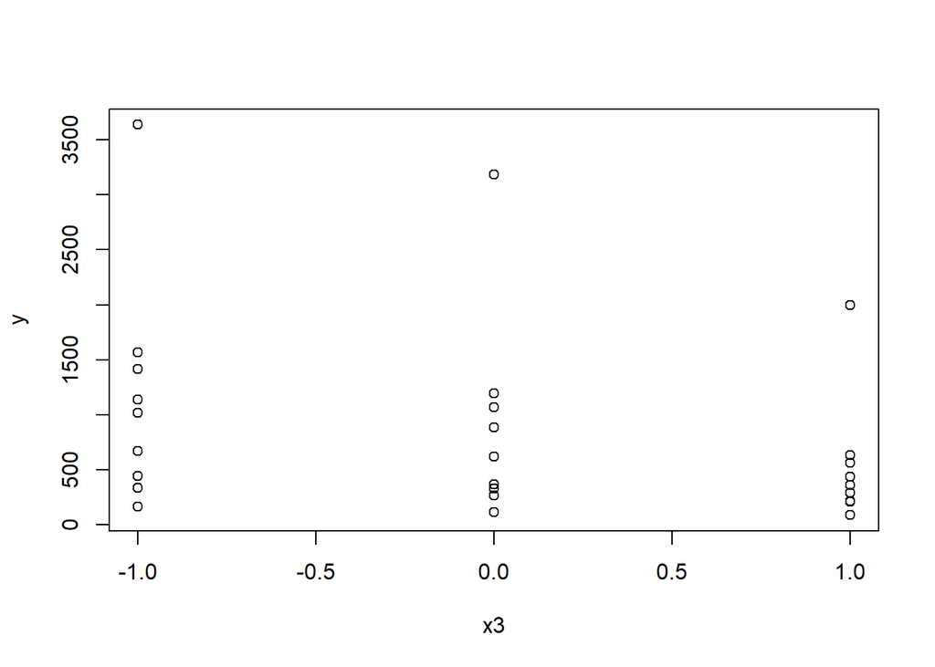

```r
plot(x3,y)
```

* Vemos que no hay varianza constante!

#### Ajustamos modelo lineal

```r
fit1 <- glm(y ~ x1 + x2 + x3)
summary(fit1)
```

```
##
## Call:
## glm(formula = y ~ x1 + x2 + x3)
##
## Deviance Residuals:
##    Min      1Q  Median      3Q     Max
## -644.6  -279.1  -150.1   199.6  1268.0
##
## Coefficients:
##             Estimate Std. Error t value Pr(>|t|)
## (Intercept)   861.33      93.95   9.168 3.83e-09 ***
## x1            660.00     115.06   5.736 7.66e-06 ***
## x2           -535.89     115.06  -4.657 0.000109 ***
## x3           -310.78     115.06  -2.701 0.012751 *
## ---
## Signif. codes:  0 '***' 0.001 '**' 0.01 '*' 0.05 '.' 0.1 ' ' 1
##
## (Dispersion parameter for gaussian family taken to be 238303.5)
##
##     Null deviance: 20229456  on 26  degrees of freedom
## Residual deviance:  5480981  on 23  degrees of freedom
## AIC: 416.59
##
## Number of Fisher Scoring iterations: 2
```

```r
library(boot)
```

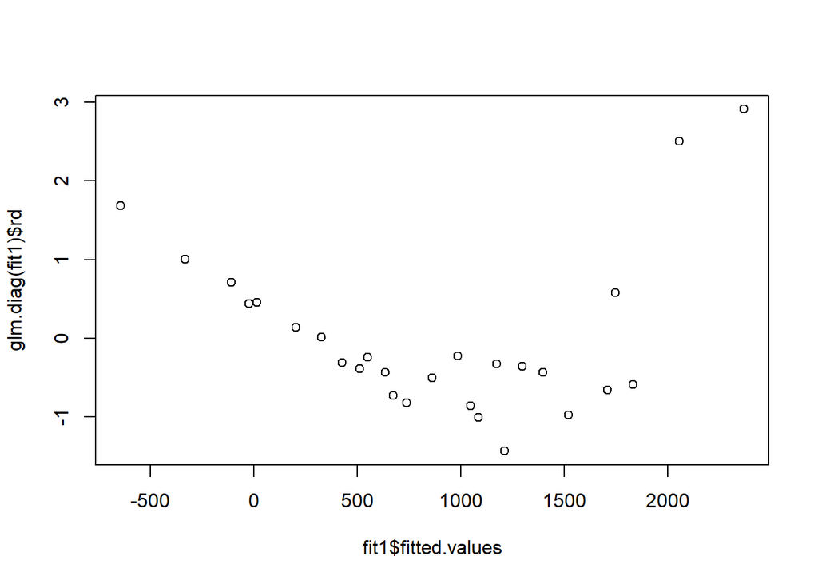

```r
plot(fit1$fitted.values,glm.diag(fit1)$rd)
```

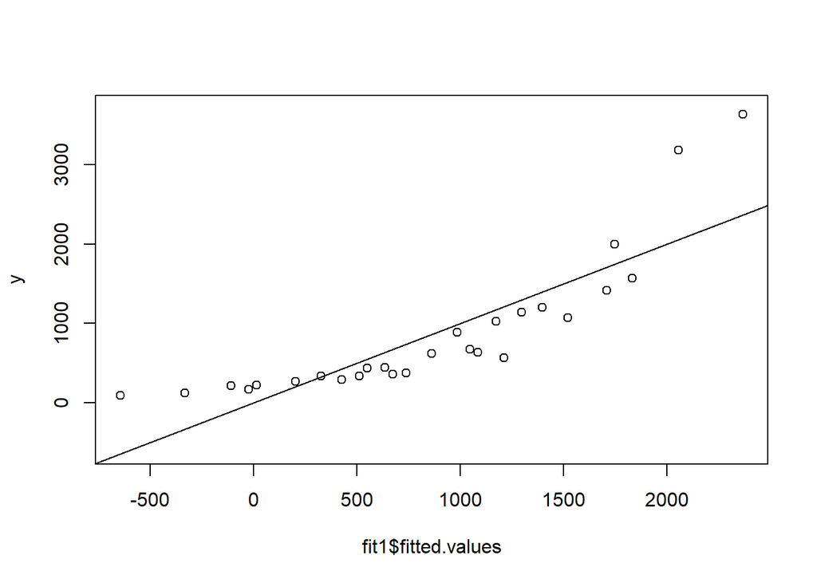

```r
plot(fit1$fitted.values,y,ylim = c(-600,3700));abline(0,1) #Vemos region de predicciones negativas que esta muy mal.
```

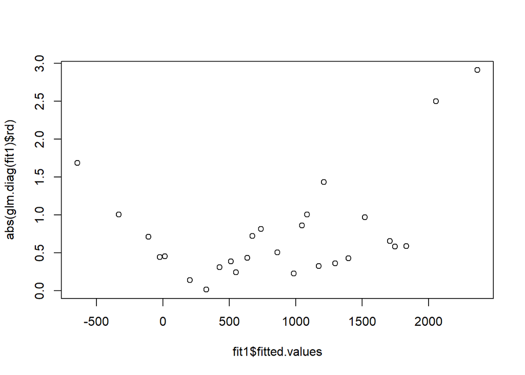

```r
plot(fit1$fitted.values,abs(glm.diag(fit1)$rd)) #Problemas estimaciones negativas.
```

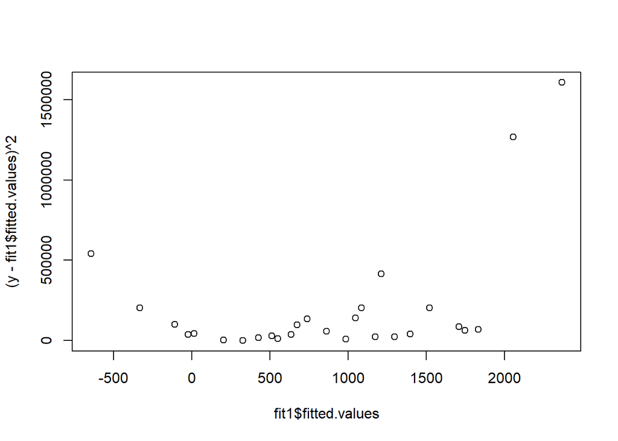

```r
plot(fit1$fitted.values,(y - fit1$fitted.values)^2) #se ve el aumento de m(y) y v(y) se justifica distribucion gamma.
```

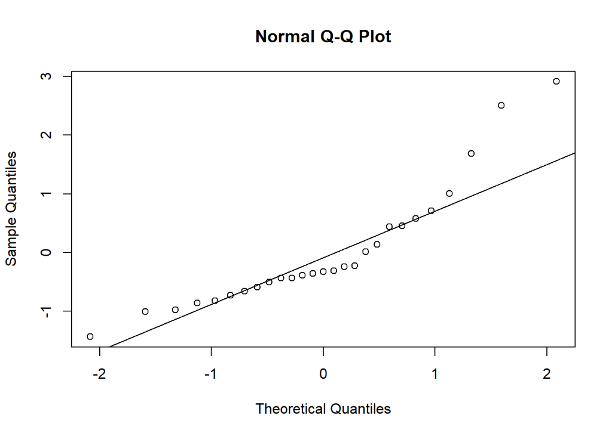

```r
qqnorm(glm.diag(fit1)$rd);qqline(glm.diag(fit1)$rd) #No se cumple normalidad
```

#### Ajustamos modelo lineal con respuesta transofrmada

```r
fit2 <- glm(log(y) ~ x1 + x2 + x3)
summary(fit2)
```

```
##
## Call:
## glm(formula = log(y) ~ x1 + x2 + x3)
##
## Deviance Residuals:
##      Min        1Q    Median        3Q       Max
## -0.43596  -0.11254   0.00811   0.11649   0.26785
##
## Coefficients:
##             Estimate Std. Error t value Pr(>|t|)
## (Intercept)  6.33466    0.03572 177.323  < 2e-16 ***
## x1           0.83238    0.04375  19.025 1.43e-15 ***
## x2          -0.63099    0.04375 -14.422 5.20e-13 ***
## x3          -0.39249    0.04375  -8.971 5.69e-09 ***
## ---
## Signif. codes:  0 '***' 0.001 '**' 0.01 '*' 0.05 '.' 0.1 ' ' 1
##
## (Dispersion parameter for gaussian family taken to be 0.03445732)
##
##     Null deviance: 23.20369  on 26  degrees of freedom
## Residual deviance:  0.79252  on 23  degrees of freedom
## AIC: -8.6435
##
## Number of Fisher Scoring iterations: 2
```

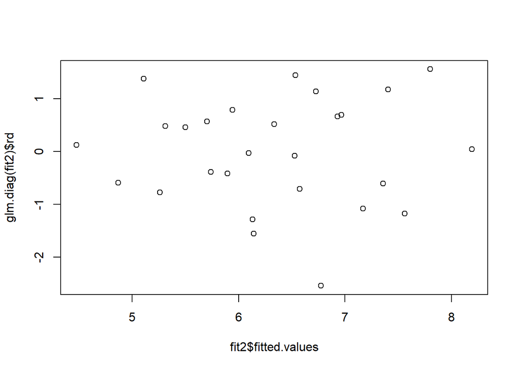

```r
plot(fit2$fitted.values,glm.diag(fit2)$rd)
```

* Vemos que no hay tendencia y solo se presenta un valor por debajo de -2.

#### Ajustamos un glm con distribucion gamma y link = log

- Razonable si vemos que la variabilidad aumenta con la media.

```r
fit3 <- glm(y ~ x1 + x2 + x3, family = Gamma(link = "log"))
summary(fit3)
```

```
##
## Call:
## glm(formula = y ~ x1 + x2 + x3, family = Gamma(link = "log"))
##
## Deviance Residuals:
##      Min        1Q    Median        3Q       Max
## -0.43391  -0.11553  -0.00922   0.10260   0.25342
##
## Coefficients:
##             Estimate Std. Error t value Pr(>|t|)
## (Intercept)  6.34891    0.03422 185.511  < 2e-16 ***
## x1           0.84251    0.04192  20.100 4.34e-16 ***
## x2          -0.63132    0.04192 -15.062 2.10e-13 ***
## x3          -0.38513    0.04192  -9.188 3.68e-09 ***
## ---
## Signif. codes:  0 '***' 0.001 '**' 0.01 '*' 0.05 '.' 0.1 ' ' 1
##
## (Dispersion parameter for Gamma family taken to be 0.0316243)
##
##     Null deviance: 22.88613  on 26  degrees of freedom
## Residual deviance:  0.76939  on 23  degrees of freedom
## AIC: 332.76
##
## Number of Fisher Scoring iterations: 5
```

- Mejor ajuste como consecuencia de que los errores estandares de la estimacion de los coeficientes son mas chicos.
- Coeficientes dan muy parecidos en ambos. Hasta Bo que era el que podia variar por ser insesgado es muy parecido.
- No comparar AIC cuando la distribucion cambia, algunos dicen que no importa mientras la variable respuesta sea la misma.

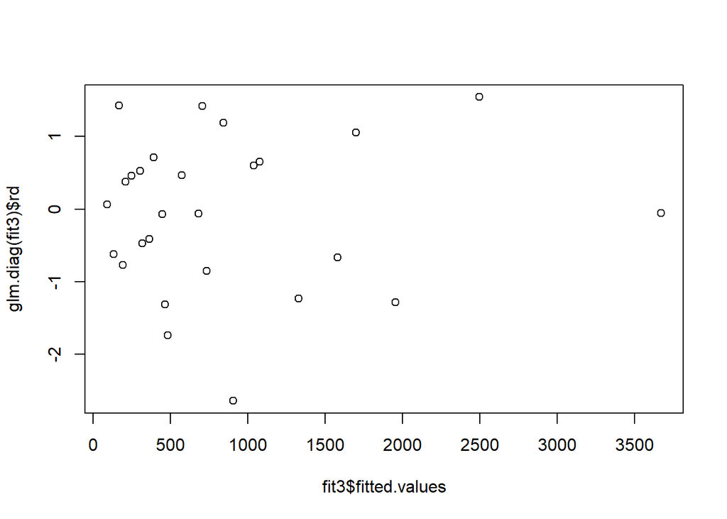

```r
plot(fit3$fitted.values,glm.diag(fit3)$rd)
```

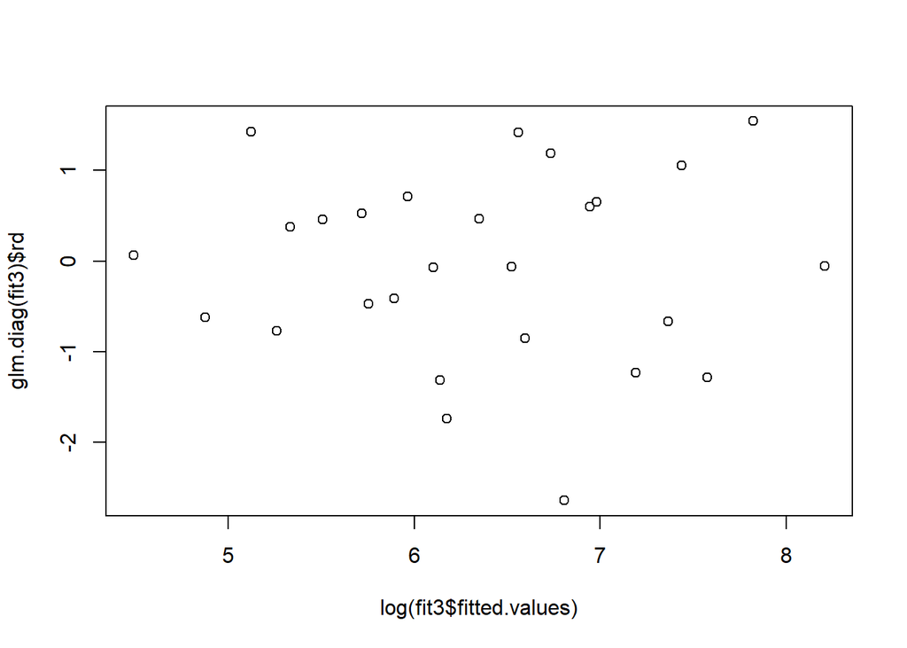

```r
plot(log(fit3$fitted.values),glm.diag(fit3)$rd) # Transforamcion de escala que permite ver mejor distribuidos los datos en el eje x. No patron :)
```

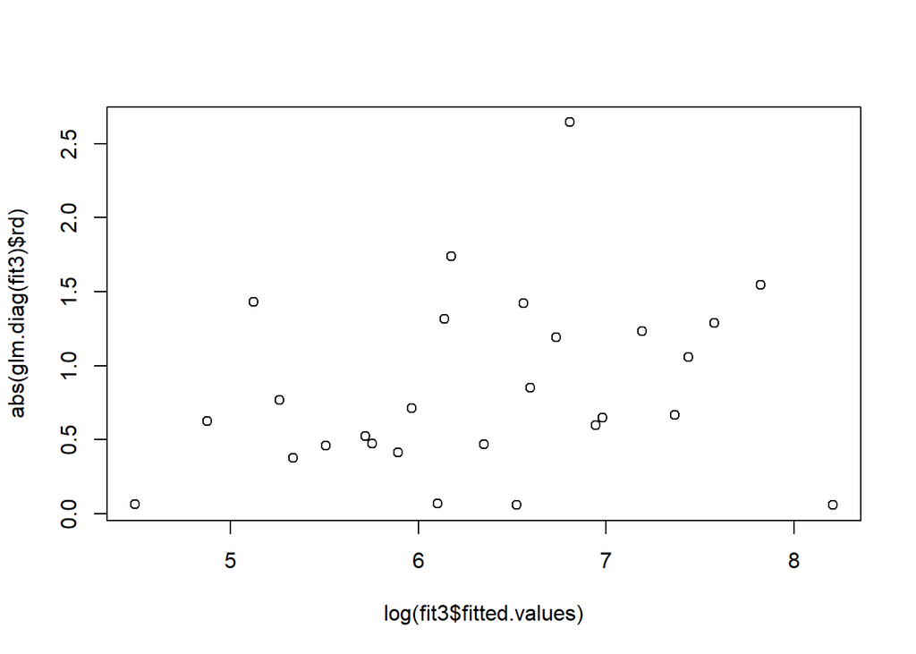

```r
plot(log(fit3$fitted.values),abs(glm.diag(fit3)$rd))
```

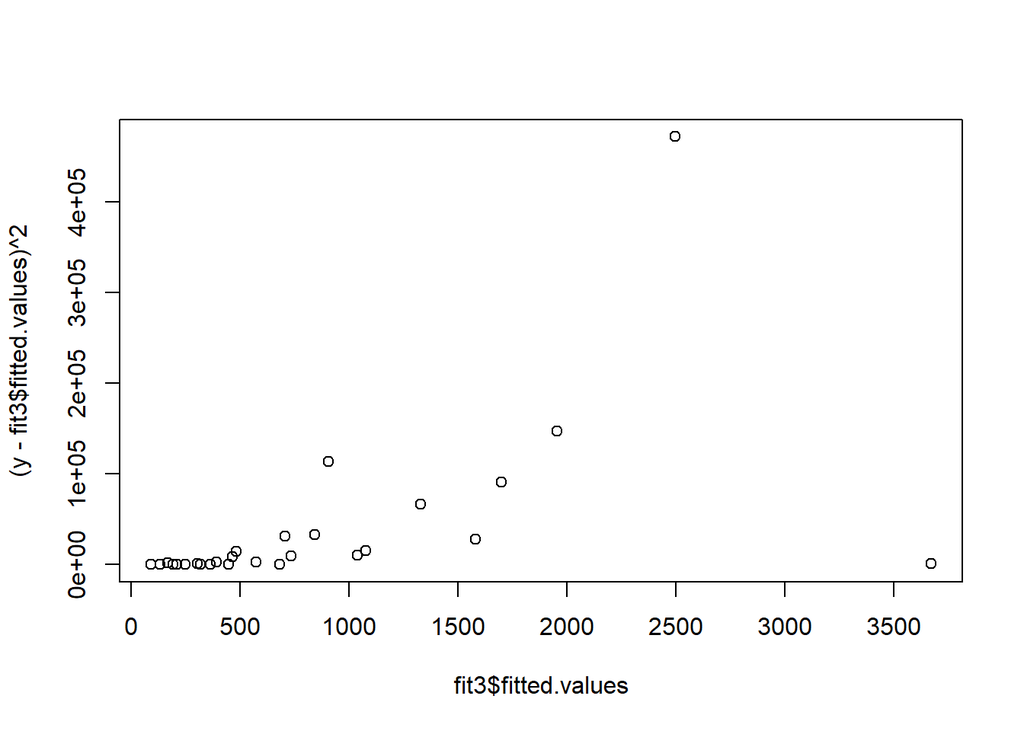

```r
plot(fit3$fitted.values,(y - fit3$fitted.values)^2) # Se ve la relacion media varianza que propusimos, por lo que seria correcto. Relacion cuadratica del modelo gamma.
```

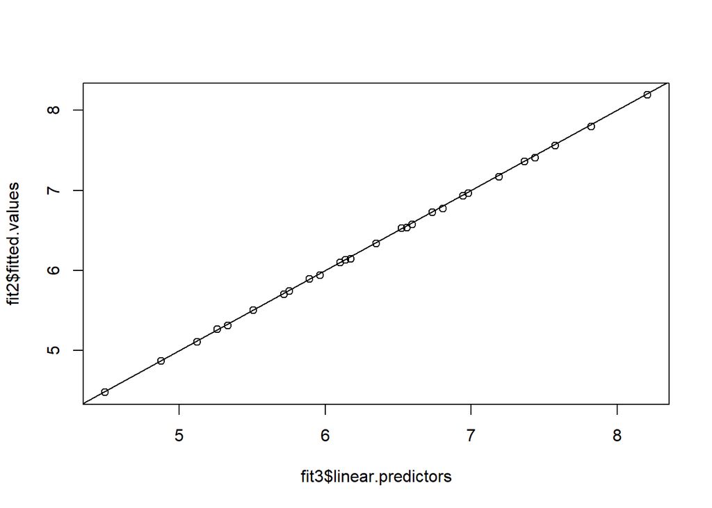

```r
plot(fit3$linear.predictors,fit2$fitted.values);abline(0,1) # Estimaciones de modelo 2 y 3 dan muy parecidas, se cumple lo teorico del principio entre modelo de variable transformada y el MLG
```

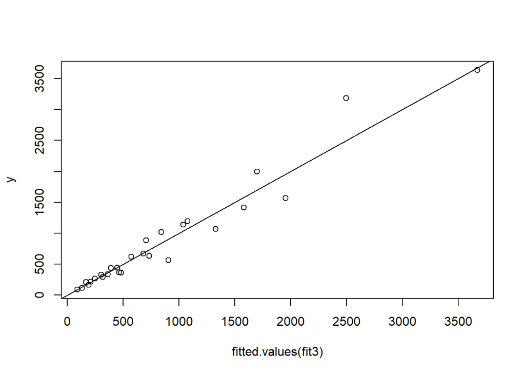

```r
plot(fitted.values(fit3),y);abline(0,1) # Muy bien predicciones vs observados cerca de la recta de 45 grados.
```

* Vemos que no hay patron, por lo que es correcto el modelo.

#### Bondad de ajuste

```r
library(MASS)
gamma.dispersion(fit3) # estima ϕ por máxima verosimilitud
```

```
## [1] 0.02836196
```

```r
fit3$deviance
```

```
## [1] 0.7693924
```

```r
dev_esc <- fit3$deviance/gamma.dispersion(fit3)
1-pchisq(dev_esc,23)
```

```
## [1] 0.250575
```

- Prueba de hipotesis:
  - Ho = Modelo es adecuado
  - H1 = Modelo no es adecuado
- La muestra no reune evidencias significativas para rechazar la hipotesis nula por lo que se acepta que el modelo es adecuado.

```r
n2 <-(fit3$linear.predictors)^2 #Prueba formal incluyendo al eta
fitn2 <- glm(y ~ x1 + x2 + x3 + n2, family = Gamma(link = "log"))
summary(fitn2)
```

```
##
## Call:
## glm(formula = y ~ x1 + x2 + x3 + n2, family = Gamma(link = "log"))
##
## Deviance Residuals:
##      Min        1Q    Median        3Q       Max
## -0.42290  -0.12544   0.00067   0.11083   0.24795
##
## Coefficients:
##             Estimate Std. Error t value Pr(>|t|)
## (Intercept)  5.61424    1.47643   3.803 0.000975 ***
## x1           0.65127    0.38614   1.687 0.105805
## x2          -0.48740    0.29073  -1.676 0.107797
## x3          -0.29896    0.18056  -1.656 0.111981
## n2           0.01785    0.03587   0.498 0.623674
## ---
## Signif. codes:  0 '***' 0.001 '**' 0.01 '*' 0.05 '.' 0.1 ' ' 1
##
## (Dispersion parameter for Gamma family taken to be 0.03291585)
##
##     Null deviance: 22.88613  on 26  degrees of freedom
## Residual deviance:  0.76134  on 22  degrees of freedom
## AIC: 334.47
##
## Number of Fisher Scoring iterations: 5
```

- Vemos si la funcion de enlace es adecuada por lo general lo hago cunado hay alguna falla en el modelo.
- Si el temino de n2 no es significativo, luego el enlace es adecuado.
- Prueba de hipotesis:
  - Ho = El enlace es adecuado
  - H1 = El enlace no es adecuado

```r
anova(fitn2,test = "F")
```

```
## Analysis of Deviance Table
##
## Model: Gamma, link: log
##
## Response: y
##
## Terms added sequentially (first to last)
##
##
##      Df Deviance Resid. Df Resid. Dev        F    Pr(>F)
## NULL                    26    22.8861
## x1    1  12.6758        25    10.2104 385.0959 1.981e-15 ***
## x2    1   6.8645        24     3.3459 208.5470 1.052e-12 ***
## x3    1   2.5765        23     0.7694  78.2746 1.067e-08 ***
## n2    1   0.0080        22     0.7613   0.2445    0.6259
## ---
## Signif. codes:  0 '***' 0.001 '**' 0.01 '*' 0.05 '.' 0.1 ' ' 1
```

- No significativa incorporacion al modelo, el enlace es adecuado.

```r
anova(fit3,test = "F")
```

```
## Analysis of Deviance Table
##
## Model: Gamma, link: log
##
## Response: y
##
## Terms added sequentially (first to last)
##
##
##      Df Deviance Resid. Df Resid. Dev       F    Pr(>F)
## NULL                    26    22.8861
## x1    1  12.6758        25    10.2104 400.823 4.729e-16 ***
## x2    1   6.8645        24     3.3459 217.064 3.331e-13 ***
## x3    1   2.5765        23     0.7694  81.471 5.093e-09 ***
## ---
## Signif. codes:  0 '***' 0.001 '**' 0.01 '*' 0.05 '.' 0.1 ' ' 1
```

- En la Gamma phi desconocido por eso test F, en binomial qchisk porque phi es conocido

```r
exp(coef(fit3))
```

```
## (Intercept)          x1          x2          x3
## 571.8703665   2.3221878   0.5318889   0.6803594
```

```r
exp(-coef(fit3))
```

```
## (Intercept)          x1          x2          x3
## 0.001748648 0.430628396 1.880091870 1.469811408
```

- Cuando X1 aumenta en una unidad la respuesta aumenta en un factor de 2,32 cuando x2 y x3 permanecen constantes.
- Cuando X2 disminuye en una unidad la respuesta aumenta en un factor de 1,88 cuando x1 y x2 permanecen constantes.
- Cuando X3 disminuye en una unidad la respuesta aumenta en un factor de 1,46 cuando x2 y x3 permanecen constantes.

## Normal Inversa

```r
#(enlace canónico, link = “1/mu^2”))
#(link = “identity”)
#(link = “log”)
#(link = “inverse”)
```